# A Natural Look into our AI-Driven World: An Image Classification Lookthrough

[figure not shown]

AI is changing the world as we know it. Companies look to train models based on recurring patterns, and visuals such as images make for great training material to help them identify and improve upon their ability to predict patterns and accuracy. For this project, we will be using Tensorflow. Tensorflow is an ML package from Google that enables analysts and engineers to develop everything from Simple Neural Networks to Image Classification. We're gonna focus on the latter, so we will concentrate on using Keras.

The dataset used: https://www.kaggle.com/datasets/puneet6060/intel-image-classification

# Let's start by loading in the packages we'll need for today.

```python
import numpy as np # linear algebra
import pandas as pd # data processing, CSV file I/O (e.g. pd.read_csv)
import tensorflow as tf #The ML package we'll use today
import matplotlib.pyplot as plt #To plot Training and Validation Accuracy
from matplotlib import image
import os
from sklearn.metrics import confusion_matrix
import seaborn as sn; sn.set(font_scale=1.4)
from sklearn.utils import shuffle
import cv2
from tqdm import tqdm

#verifying image filenames for each of the training and test classes
import os
for dirname, _, filenames in os.walk('/kaggle/input'):
    for filename in filenames:
        print(os.path.join(dirname, filename))
        break
```

Now that we got our packages set up, it's time to first load the data and then pre-process it for our visual classification. Let's first create the class types.

# First, let's get ourselves some class types.

```python
batch_size = 128
img_height = 150
img_width = 150
```

```python
train_ds = tf.keras.preprocessing.image_dataset_from_directory(
    '/Users/noelmccann/Downloads/NLM_Python/Intel/intel-image-classification/seg_train/seg_train',
    batch_size=batch_size,
    image_size=(img_height, img_width),
    seed=56
)
```

```
Found 14034 files belonging to 6 classes.
```

```python
test_ds = tf.keras.utils.image_dataset_from_directory(
    '/Users/noelmccann/Downloads/NLM_Python/Intel/intel-image-classification/seg_test/seg_test',
    batch_size=batch_size,
    image_size=(img_height, img_width),
    seed=56
)
```

```
Found 3000 files belonging to 6 classes.
```

Per our ds functions, we get 14,034 training images and 3,000 test images. But what are those 6 classes they belong to?

Find out now!

```python
class_names = train_ds.class_names
class_names_label = {class_name:i for i, class_name in enumerate(class_names)}

nb_classes = len(class_names)
print(class_names)
```

```
['buildings', 'forest', 'glacier', 'mountain', 'sea', 'street']
```

# Now let's see what we got for our data.

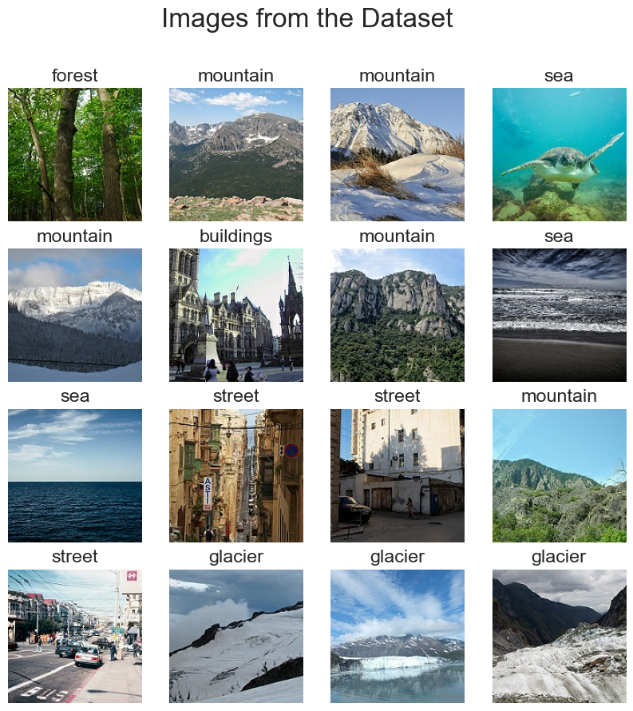

```python
fig = plt.figure(figsize=(10, 10))
fig.suptitle("Images from the Dataset", fontsize=24)
for images, labels in train_ds.take(1):
    for i in range(16):
        ax = plt.subplot(4, 4, i + 1)
        plt.imshow(images[i].numpy().astype("uint8"))
        plt.title(class_names[labels[i]])
        plt.axis("off")
```

Interesting. The grid above gives us a visual taste of the images we will be feeding our model. As you can see, there's a label on top of each relevant image in the grid. Let's keep going.

```python
for image_batch, labels_batch in train_ds:
    print(image_batch.shape)
    print(labels_batch.shape)
    break
```

```
(128, 150, 150, 3)
(128,)
```

We can verify that the training set's images will be 150 by 150 in size and contain 128 per batch. Finally, let's make our final preparations for pre-processing the data we will run.

```python
img_size = (150, 150)
```

```python
def load_data():
    datasets = ['/Users/noelmccann/Downloads/NLM_Python/Intel/intel-image-classification/seg_train/seg_train',
                '/Users/noelmccann/Downloads/NLM_Python/Intel/intel-image-classification/seg_test/seg_test']
    output = []

    # Iterate through training and test sets
    for dataset in datasets:

        images = []
        labels = []

        print("Loading {}".format(dataset))

        # Iterate through each folder corresponding to a category
        for folder in os.listdir(dataset):
            label = class_names_label[folder]

            # Iterate through each image
            for file in tqdm(os.listdir(os.path.join(dataset, folder))):

                # Identifying an image's path
                img_path = os.path.join(os.path.join(dataset, folder), file)

                # Resizing the image
                image = cv2.imread(img_path)
                image = cv2.cvtColor(image, cv2.COLOR_BGR2RGB)
                image = cv2.resize(image, img_size)

                # Append the image and its corresponding label to the output
                images.append(image)
                labels.append(label)

        images = np.array(images, dtype = 'float32')
        labels = np.array(labels, dtype = 'int32')

        output.append((images, labels))

    return output
```

```python
(train_images, train_labels), (test_images, test_labels) = load_data()
```

```
Loading /Users/noelmccann/Downloads/NLM_Python/Intel/intel-image-classification/seg_train/seg_train
```

```
Loading /Users/noelmccann/Downloads/NLM_Python/Intel/intel-image-classification/seg_test/seg_test
```

Now that the data is fully loaded, we can shuffle the images to remove potential bias.

```python
train_images, train_labels = shuffle(train_images, train_labels, random_state=25)
```

# Let's Go with the Flow

Now that we got what we needed from our dataset, it's time to use Tensorflow to classify some photos.

Let's start off by looking at the current state of our training and test sets.

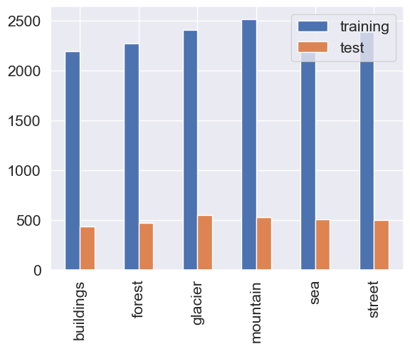

```python
_, train_counts = np.unique(train_labels, return_counts=True)
_, test_counts = np.unique(test_labels, return_counts=True)
pd.DataFrame({'training': train_counts,
                    'test': test_counts},
             index=class_names
            ).plot.bar()
plt.show()
```

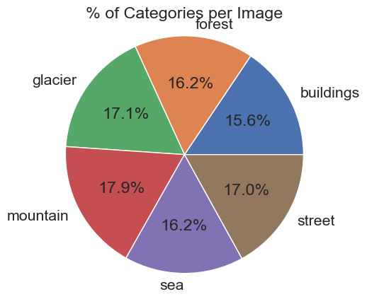

```python
plt.pie(train_counts,
        explode=(0, 0, 0, 0, 0, 0) ,
        labels=class_names,
        autopct='%1.1f%%')
plt.axis('equal')
plt.title('% of Categories per Image')
plt.show()
```

Here, we have a glimpse of what we can expect when it comes to the number of photos per category for both the training and testing sets. We can expect Mountains to make up the bulk of the images classified, however the difference in percentages between categories is negligible.

Let's start by scaling the images and then running an autotune, which will help dynamically tune and optimize the value of the data being calculated when we run Keras.

```python
train_images = train_images / 255.0
test_images = test_images / 255.0
```

```python
AUTOTUNE = tf.data.AUTOTUNE  #prompts tf.data runtime to tune the value dynamically at runtime

train_ds = train_ds.cache().shuffle(1000).prefetch(buffer_size=AUTOTUNE)
test_ds = test_ds.cache().prefetch(buffer_size=AUTOTUNE)
```

Layers used for this Sequential function:

- Conv2D: The features which will be extracted from the image (The amount of filters of size x by x).
- MaxPooling2D: The images get half sized.
- Flatten: Transforms the format of the images from a 2d-array to a 1d-array.
- Relu : Returns max(x, 0) if given a value x.
- Softmax: 6 neurons, probability that the image belongs to one of the classes.

```python
num_classes = len(class_names)

model = tf.keras.Sequential([
    tf.keras.layers.Conv2D(32, (3, 3), activation = 'relu', input_shape = (150, 150, 3)),
    tf.keras.layers.MaxPooling2D(2,2),
    tf.keras.layers.Conv2D(32, (3, 3), activation = 'relu'),
    tf.keras.layers.MaxPooling2D(2,2),
    tf.keras.layers.Flatten(),
    tf.keras.layers.Dense(128, activation=tf.nn.relu),
    tf.keras.layers.Dense(6, activation=tf.nn.softmax)
])
```

```python
model.compile(optimizer = 'adam', loss = 'sparse_categorical_crossentropy', metrics=['accuracy'])
```

```python
model.summary()
```

```
Model: "sequential"
_________________________________________________________________
 Layer (type)                Output Shape              Param #
=================================================================
 conv2d (Conv2D)             (None, 148, 148, 32)      896

 max_pooling2d (MaxPooling2  (None, 74, 74, 32)        0
 D)

 conv2d_1 (Conv2D)           (None, 72, 72, 32)        9248

 max_pooling2d_1 (MaxPoolin  (None, 36, 36, 32)        0
 g2D)

 flatten (Flatten)           (None, 41472)             0

 dense (Dense)               (None, 128)               5308544

 dense_1 (Dense)             (None, 6)                 774

=================================================================
Total params: 5319462 (20.29 MB)
Trainable params: 5319462 (20.29 MB)
Non-trainable params: 0 (0.00 Byte)
_________________________________________________________________
```

With over 5 million trainable paramaters, we are ready to take a crack at fitting the model. We will use 16 epochs, or testing iterations, and a validation split of 20% of total images for this run.

```python
epochs = 16
history = model.fit(
    train_images,
    train_labels,
    batch_size=128,
    epochs=epochs,
    validation_split = 0.2)
```

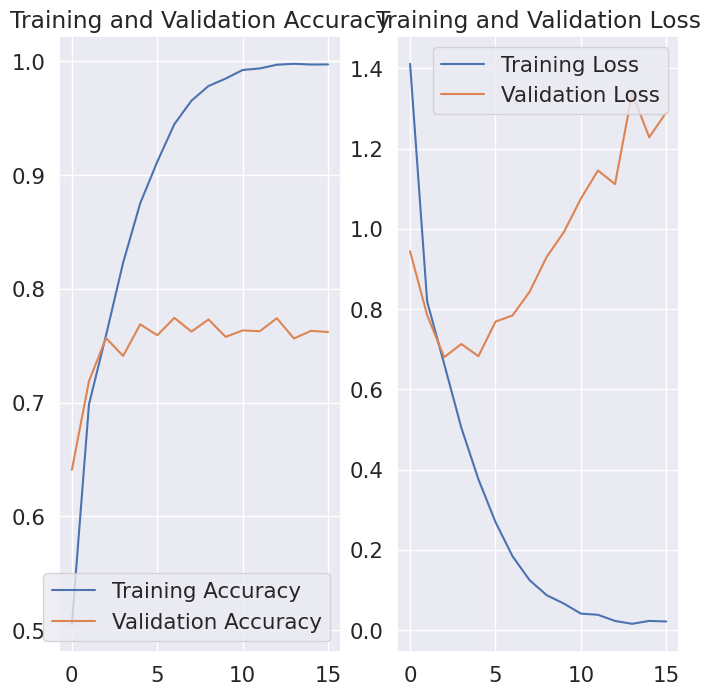

```python
#Historical record of training and validation accuracy + loss
acc = history.history['accuracy']
val_acc = history.history['val_accuracy']

loss = history.history['loss']
val_loss = history.history['val_loss']

#To record the number of iterations
epochs_range = range(epochs)

plt.figure(figsize=(8, 8))
plt.subplot(1, 2, 1)
plt.plot(epochs_range, acc, label='Training Accuracy')
plt.plot(epochs_range, val_acc, label='Validation Accuracy')
plt.legend(loc='lower right')
plt.title('Training and Validation Accuracy')

plt.subplot(1, 2, 2)
plt.plot(epochs_range, loss, label='Training Loss')
plt.plot(epochs_range, val_loss, label='Validation Loss')
plt.legend(loc='upper right')
plt.title('Training and Validation Loss')
plt.show()
```

```python
test_loss = model.evaluate(test_images, test_labels)
```

[output not shown]

In our first run, the accuracy of the model is 74.8%. Not bad, but this suggests that there are opportunities for improvement, especially when it comes to overfitting in the training sets and addressing the loss in the test sets.

# Checking Our Work

Things are starting to come together in our quest to classify the natural scenes of the world. But what can we do to ensure we can have even better accuracy for our training and test data? Let's double-check together.

```python
predictions = model.predict(test_images) # This creates a vector of probabilities
pred_labels = np.argmax(predictions, axis = 1) #This label selects the highest level of probability. This will come in handy soon.
```

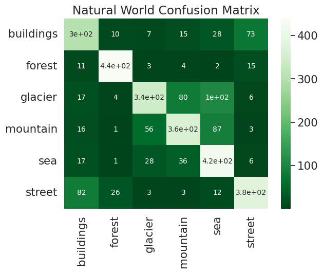

```python
df_cm = confusion_matrix(test_labels, pred_labels)
ax = plt.axes()
sn.heatmap(df_cm, annot=True, cmap="Greens_r",
           annot_kws={"size": 10},
           xticklabels=class_names,
           yticklabels=class_names, ax = ax)
ax.set_title('Natural World Confusion Matrix')
plt.show()
```